# Saturday

Shih-Ni Prim 2020-10-16

- Introduction
- Setting the Value for the Parameter
- Data
- Splitting Data
- Summaries and Exploratory Data Analysis
- Fitting models
  - Regression tree
  - Boosted Tree
  - Comparison
  - Final Model

## Introduction

Now we take a look at Saturday’s analysis. This dataset contains information about [bike sharing](https://archive.ics.uci.edu/ml/datasets/Bike+Sharing+Dataset). We have a variety of predictors, including hours, temperature, humidity, weekday, holiday/workday or not, etc. In our analysis, We will use two statistical learning models–regression tree and boosted tree–to predict the count of total rental bikes `cnt`.

## Setting the Value for the Parameter

Since the current analysis is on Saturday, we first find the corresponding value for it.

```r
set.seed(7777)
i <- 0:6
dayz <- c("Sunday", "Monday", "Tuesday", "Wednesday", "Thursday", "Friday", "Saturday")
df <- as.data.frame(cbind(i, dayz))
weekdayNum <- df$i[df$dayz == params$weekday]
print(weekdayNum)
```

```
## [1] "6"
```

## Data

Now we read in the data. Two datasets are listed on [the link](https://archive.ics.uci.edu/ml/datasets/Bike+Sharing+Dataset), one including the `hr` variable, and one treating each day as one observation and thus not including the `hr` variable. Since hours–the time in the day–should be a meaningful predictor for the number of bike rentals, we use the dataset with the `hr` variable

```r
bikes <- read_csv("../Bike-Sharing-Dataset/hour.csv")
# head(bikes)
analysis <- bikes %>% filter(weekday == weekdayNum) %>% select(-casual, -registered) %>% select(dteday, weekday, everything())
# head(analysis)
```

## Splitting Data

We first split up the data into two sets: training and test sets. The training set has about 70% of the data, and the test set has about 30%. Splitting up the data is important, because we want to test the model on a set that is not used in training, otherwise we risk overfitting.

```r
train <- sample(1:nrow(analysis), size = nrow(analysis)*0.7)
test <- setdiff(1:nrow(analysis), train)

bikeTrain <- analysis[train,]
bikeTest <- analysis[test,]
```

## Summaries and Exploratory Data Analysis

To decide which variables to include in our models, we first take a quick look at the data. We can look at summaries of numerical variables.

```r
summary(bikeTrain)
```

```
##      dteday              weekday     instant          season            yr
##  Min.   :2011-01-01   Min.   :6   Min.   :    1   Min.   :1.000   Min.   :0.0000
##  1st Qu.:2011-06-25   1st Qu.:6   1st Qu.: 4128   1st Qu.:1.000   1st Qu.:0.0000
##  Median :2011-12-31   Median :6   Median : 8622   Median :2.000   Median :0.0000
##  Mean   :2011-12-26   Mean   :6   Mean   : 8540   Mean   :2.464   Mean   :0.4898
##  3rd Qu.:2012-06-23   3rd Qu.:6   3rd Qu.:12834   3rd Qu.:3.000   3rd Qu.:1.0000
##  Max.   :2012-12-29   Max.   :6   Max.   :17331   Max.   :4.000   Max.   :1.0000
##       mnth             hr           holiday    workingday   weathersit         temp
##  Min.   : 1.00   Min.   : 0.00   Min.   :0   Min.   :0    Min.   :1.000   Min.   :0.0200
##  1st Qu.: 3.00   1st Qu.: 6.00   1st Qu.:0   1st Qu.:0    1st Qu.:1.000   1st Qu.:0.3200
##  Median : 6.00   Median :12.00   Median :0   Median :0    Median :1.000   Median :0.4800
##  Mean   : 6.48   Mean   :11.67   Mean   :0   Mean   :0    Mean   :1.409   Mean   :0.4848
##  3rd Qu.: 9.00   3rd Qu.:18.00   3rd Qu.:0   3rd Qu.:0    3rd Qu.:2.000   3rd Qu.:0.6400
##  Max.   :12.00   Max.   :23.00   Max.   :0   Max.   :0    Max.   :3.000   Max.   :1.0000
##      atemp             hum           windspeed           cnt
##  Min.   :0.0000   Min.   :0.1200   Min.   :0.0000   Min.   :  1.0
##  1st Qu.:0.3182   1st Qu.:0.4500   1st Qu.:0.1045   1st Qu.: 43.0
##  Median :0.4697   Median :0.6200   Median :0.1940   Median :133.0
##  Mean   :0.4646   Mean   :0.6197   Mean   :0.1951   Mean   :190.8
##  3rd Qu.:0.6212   3rd Qu.:0.7900   3rd Qu.:0.2836   3rd Qu.:300.0
##  Max.   :0.8939   Max.   :1.0000   Max.   :0.8358   Max.   :783.0
```

Below we look at three plots. The first plot shows the histogram of bike rentals (`cnt`) on Saturday. The second plot shows that `cnt` does vary in different hours. The third plot shows that `cnt` varies between the two years. So we know we should keep `hr` and `yr` as predictors.

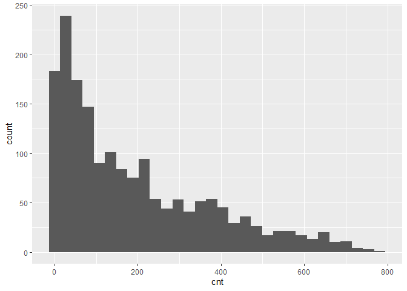

```r
ggplot(bikeTrain, mapping = aes(x = cnt)) + geom_histogram()
```

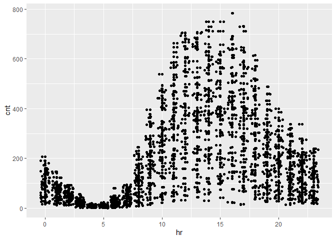

```r
ggplot(bikeTrain, aes(x = hr, y = cnt)) + geom_point() + geom_jitter()
```

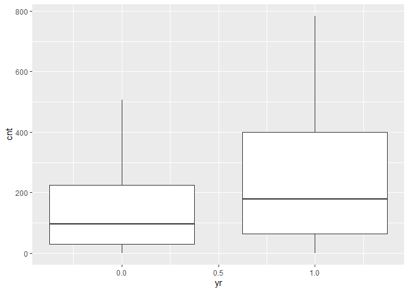

```r
ggplot(bikeTrain, aes(x = yr, y = cnt)) + geom_boxplot(aes(group = yr))
```

Next we look at correlations of different variables. Weather and windspeed do not seem correlate, so we will keep both `weathersit` and `windspeed`.

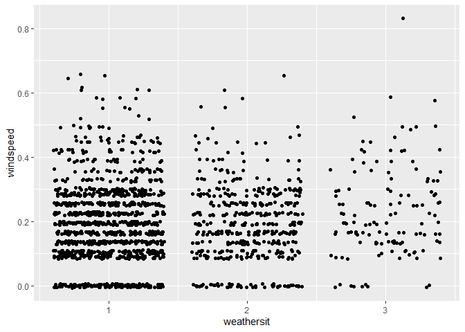

```r
ggplot(bikeTrain, aes(x = weathersit, y = windspeed)) + geom_jitter()
```

```r
cor(bikeTrain$season, bikeTrain$mnth)
```

```
## [1] 0.8063518
```

```r
cor(bikeTrain$holiday, bikeTrain$workingday)
cor(bikeTrain$temp, bikeTrain$atemp)
```

[output not shown]

```
## [1] 0.9922486
```

The variance of `workingday` and `holiday` are too small and probably not good predictors.

```r
var(bikeTrain$holiday)
```

```
## [1] 0
```

```r
var(bikeTrain$workingday)
```

```
## [1] 0
```

Also, `instant` and `dteday` are for record-keeping. Thus, we decide to keep the following variables as the predictors: `season`, `yr`, `hr`, `weathersit`, `atemp`, `hum`, and `windspeed`.

```r
bikeTrain <- select(bikeTrain, season, yr, hr, weathersit, atemp, hum, windspeed, cnt)
bikeTest <- select(bikeTest, season, yr, hr, weathersit, atemp, hum, windspeed, cnt)
```

## Fitting models

Now we have a final training set and have chosen the predictors, we can use two models–regression tree and boosted tree–to fit the training data.

### Regression tree

A regression tree is one of the tree based methods for supervised learning with the goal of predicting a continuous response. It splits up predictor space into different regions, and the prediction of each region is often the mean of observations in that region.

```r
modelLookup("rpart")

bikeTree <- train(cnt ~ ., data = bikeTrain, method = "rpart", trControl = trainControl(method = "LOOCV"), tuneGrid = expand.grid(cp = seq(0.01, 0.02, 0.001)))
```

Below we can see the final model; the resulting RMSE, Rsquared, and MAE of different cp; and a plot that shows the relationship between cp and RMSE.

```r
bikeTree$finalModel
```

```
## n= 1758
##
## node), split, n, deviance, yval
##       * denotes terminal node
##
##   1) root 1758 56585800.0 190.77990
##     2) hr< 8.5 642  1374935.0  46.78972 *
##     3) hr>=8.5 1116 34242950.0 273.61290
##       6) atemp< 0.4621 507  6924617.0 163.94280
##        12) hr>=18.5 192   693775.0 101.62500 *
##        13) hr< 18.5 315  5030727.0 201.92700
##          26) atemp< 0.29545 129   611626.9 125.02330 *
##          27) atemp>=0.29545 186  3127042.0 255.26340
##            54) yr< 0.5 110   722442.9 182.97270 *
##            55) yr>=0.5 76   997719.2 359.89470 *
##       7) atemp>=0.4621 609 16143750.0 364.91460
##        14) hr>=18.5 184  1306232.0 226.83150 *
##        15) hr< 18.5 425  9810302.0 424.69650
##          30) yr< 0.5 203  2108084.0 326.00000 *
##          31) yr>=0.5 222  3916613.0 514.94590
##            62) hum>=0.685 32   372335.7 353.40620 *
##            63) hum< 0.685 190  2568597.0 542.15260
##             126) hr< 10.5 25   113242.2 391.44000 *
##             127) hr>=10.5 165  1801458.0 564.98790 *
```

```r
bikeTree
```

```
## CART
##
## 1758 samples
##    7 predictor
##
## No pre-processing
## Resampling: Leave-One-Out Cross-Validation
## Summary of sample sizes: 1757, 1757, 1757, 1757, 1757, 1757, ...
## Resampling results across tuning parameters:
##
##   cp     RMSE      Rsquared   MAE
##   0.010  77.43742  0.8137188  58.19536
##   0.011  79.03319  0.8061955  59.03842
##   0.012  79.83696  0.8019993  59.85002
##   0.013  79.83696  0.8019993  59.85002
##   0.014  80.01667  0.8011178  59.92878
##   0.015  80.01667  0.8011178  59.92878
##   0.016  81.23130  0.7951441  60.28603
##   0.017  82.92198  0.7870765  61.37413
##   0.018  82.88164  0.7865968  61.50423
##   0.019  82.72525  0.7873994  61.40857
##   0.020  82.72525  0.7873994  61.40857
##
## RMSE was used to select the optimal model using the smallest value.
## The final value used for the model was cp = 0.01.
```

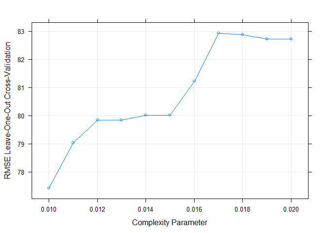

```r
plot(bikeTree)
```

Finally we use the model to predict `cnt` on the test data and calculate RMSE to check the fit of the model.

```r
predTree <- predict(bikeTree, newdata = bikeTest)
treeResult <- postResample(predTree, bikeTest$cnt)
```

### Boosted Tree

A boosted tree is one of the ensemble learning methods, in which the tree grows sequentially. Each subsequent tree is combined into the previous model to produce a modified model. The predictions are updated as the tree grows.

```r
modelLookup("gbm")

grid <- expand.grid(n.trees = c(50, 100, 150), interaction.depth = 1:4, shrinkage = c(0.1, 0.01), n.minobsinnode = c(10, 15, 20))

boostedBike <- train(cnt ~  season + yr + hr + weathersit + atemp + hum + windspeed, data = bikeTrain, method = "gbm", preProcess = c("center", "scale"), trControl = trainControl(method = "repeatedcv", number = 10, repeats = 3), tuneGrid = grid, verbose = FALSE)
```

Below we can see some information about the final model, the predictors chosen and their importance, and a plot that shows how RMSE changes with different numbers of boosting iterations and tree depths.

```r
boostedBike$finalModel
```

```
## A gradient boosted model with gaussian loss function.
## 150 iterations were performed.
## There were 7 predictors of which 7 had non-zero influence.
```

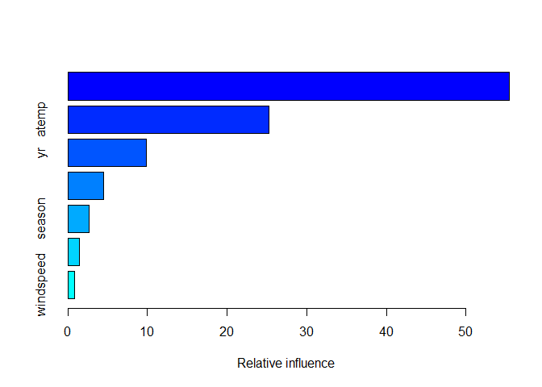

```r
summary(boostedBike)
```

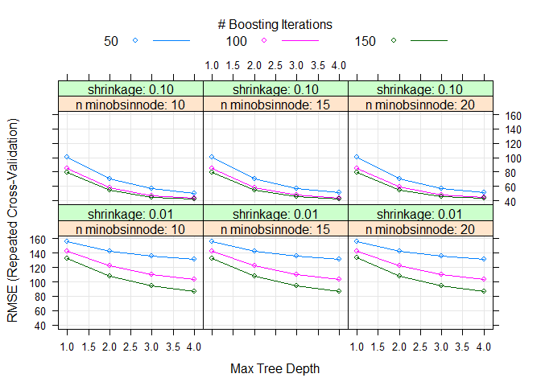

```r
plot(boostedBike)
```

Finally, we use the model to predict `cnt` on the test data and calculate RMSE to check the fit of the model.

```r
predBoostedBike <- predict(boostedBike, newdata = select(bikeTest, -cnt))
boostedResult <- postResample(predBoostedBike, bikeTest$cnt)
```

### Comparison

We can put the testing RMSE from the two models together for comparison.

```r
comparison <- data.frame(rbind(t(treeResult), t(boostedResult)))
colnames(comparison) <- c("RMSE", "Rsquared", "MAE")
rownames(comparison) <- c("Regression Tree", "Boosted Tree")
knitr::kable(comparison)
```

|  | RMSE | Rsquared | MAE |
| --- | --- | --- | --- |
| Regression Tree | 80.82609 | 0.8006307 | 60.47904 |
| Boosted Tree | 45.72799 | 0.9360725 | 31.24816 |

### Final Model

```r
# a function to generate the name of the best model
model <- function(x, y){
  xscore <- 0
  if (x[[1]] < y[[1]]) {
    xscore = xscore + 1
  }
  if (x[[2]] > y[[2]]){
    xscore = xscore + 1
  }
  if (x[[3]] < y[[3]]){
    xscore = xscore + 1
  }
  if (xscore == 2 || xscore == 3){
    final <- c("regression tree")
  } else {
    final <- c("boosted tree")
  }
  return(final)
}
# model(treeResult, boostedResult)
```

From the output, we can conclude that the boosted tree is the better model for Saturday data, because it has better performance in terms of RMSE, Rsquared, and MAE.